# Final Project Advanced Modeling

### Stepwise regression

To refine our regression model further, we use stepwise regression, which combines forward and backward selection to identify the best subset of predictors by adding or removing variables based on model fit.

```r
step_tune <- train(noVarModel,
                   data = training_noVar,
                   method = "leapSeq",
                   preProc=c('scale', 'center'),
                   tuneGrid = expand.grid(nvmax = 4:10),
                   trControl = ctrl)

# saving results
test_results$seq <- predict(step_tune, testing)

step_tune
```

```
## Linear Regression with Stepwise Selection
##
## 3464 samples
##    6 predictor
##
## Pre-processing: scaled (27), centered (27)
## Resampling: Cross-Validated (5 fold, repeated 1 times)
## Summary of sample sizes: 2771, 2772, 2770, 2772, 2771
## Resampling results across tuning parameters:
##
##   nvmax  RMSE      Rsquared   MAE
##    4     2.157940  0.3337838  1.695945
##    5     2.256538  0.2675911  1.798982
##    6     2.151679  0.3376102  1.689531
##    7     2.329025  0.2162023  1.891517
##    8     2.219466  0.2892988  1.770719
##    9     2.430237  0.1472394  1.999139
##   10     2.135124  0.3478003  1.675628
##
## RMSE was used to select the optimal model using the smallest value.
## The final value used for the model was nvmax = 10.
```

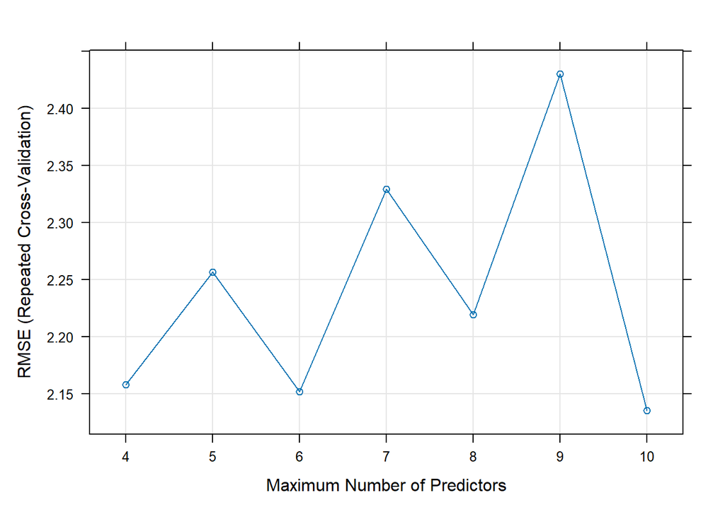

```r
plot(step_tune)
```

```r
coef(step_tune$finalModel, step_tune$bestTune$nvmax)
```

```
##    (Intercept) countryAustria countryBelgium countryCzechia countryEstonia
##     4.36403002     0.10817295     0.08895472    -0.25447850    -0.28001468
## countryFinland  countryFrance countryGermany countryHungary countryIceland
##    -0.04270873     0.08062026    -0.01697935    -0.05169134     0.02178416
## countryIreland
##    -0.02082170
```

```r
postResample(pred = test_results$seq,  obs = test_results$original)
```

```
##      RMSE  Rsquared       MAE
## 2.6765237 0.0154144 2.2276866
```

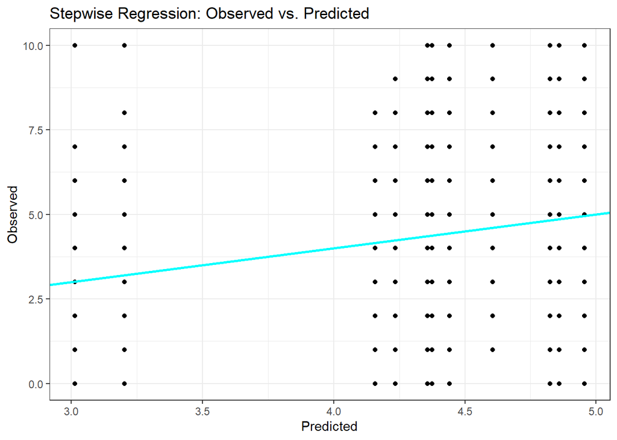

```r
ggplot(test_results, aes(x = seq, y = original)) +
  geom_point() +
  labs(title = "Stepwise Regression: Observed vs. Predicted",
       x = "Predicted", y = "Observed") +
  geom_abline(intercept = 0, slope = 1, colour = "cyan1", linewidth = 1) +
  theme_bw()
```

### Backward regression

In the final step, we apply backward selection regression using the leapBackward method to identify the most relevant predictors by starting from a full model and progressively removing the least useful ones. We test models with 4 to 10 predictors using 5-fold cross-validation.

```r
back_tune <- train(noVarModel,
                   data = training_noVar,
                   method = "leapBackward",
                   preProc = c('scale', 'center'),
                   tuneGrid = expand.grid(nvmax = 4:10),
                   trControl = ctrl)

# saving results
test_results$bw <- predict(back_tune, testing)

print(back_tune)
```

```
## Linear Regression with Backwards Selection
##
## 3464 samples
##    6 predictor
##
## Pre-processing: scaled (27), centered (27)
## Resampling: Cross-Validated (5 fold, repeated 1 times)
## Summary of sample sizes: 2772, 2771, 2771, 2771, 2771
## Resampling results across tuning parameters:
##
##   nvmax  RMSE      Rsquared   MAE
##    4     2.157403  0.3336471  1.699410
##    5     2.153243  0.3361580  1.695654
##    6     2.145414  0.3409841  1.685891
##    7     2.141384  0.3434106  1.680368
##    8     2.134975  0.3472835  1.676230
##    9     2.138546  0.3451783  1.676122
##   10     2.138501  0.3452511  1.676288
##
## RMSE was used to select the optimal model using the smallest value.
## The final value used for the model was nvmax = 8.
```

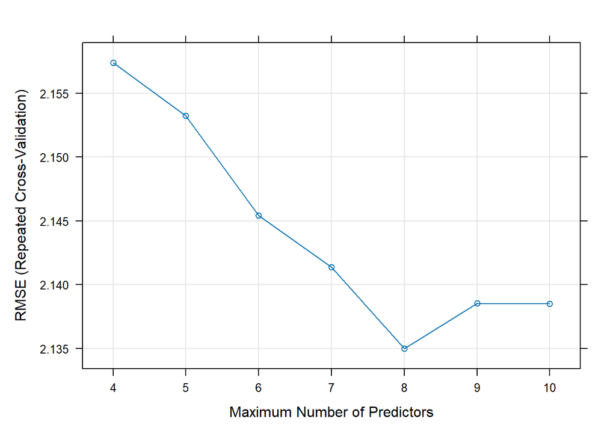

```r
plot(back_tune)
```

```r
coef(back_tune$finalModel, back_tune$bestTune$nvmax)
```

```
##            (Intercept)         countryEstonia         countryFinland
##              4.3640300             -0.1775806             -0.1578062
##          countryNorway        countrySlovenia          countrySweden
##             -0.1696677             -0.1363316             -0.1938961
##   balance_gov_personal           cc_red_group confidence_less_energy
##              0.9391381              0.8073501              0.2504317
```

```r
postResample(pred = test_results$bw, obs = test_results$original)
```

```
##      RMSE  Rsquared       MAE
## 2.1724897 0.3512465 1.7218888
```

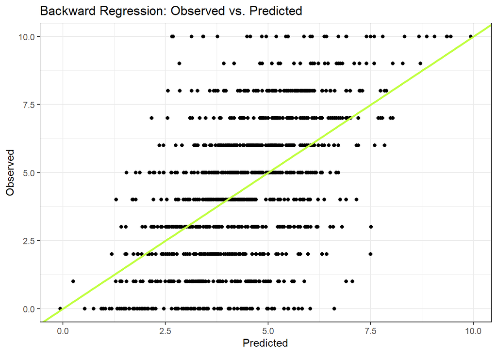

```r
ggplot(test_results, aes(x = bw, y = original)) +
  geom_point() +
  labs(title = "Backward Regression: Observed vs. Predicted",
       x = "Predicted", y = "Observed") +
  geom_abline(intercept = 0, slope = 1, colour = "olivedrab1", linewidth = 1) +
  theme_bw()
```

## ML methods

In this section, we move away from common linear regression to explore machine learning techniques that may enhance our ability to predict individual willingness to reduce personal carbon emissions. While previous models included linear regression and various regularisation strategies, we now implement alternative algorithms that can capture more complex, non-linear relationships in the data. These approaches can better account for interactions and patterns that linear models may overlook, offering the potential to improve predictive performance.

### KNN

We train the model with cross-validation and search for the optimal value of k to minimise prediction error. Initially, we are going to set the grid to a wider range of values in order to be able to better compare and narrow it down later.

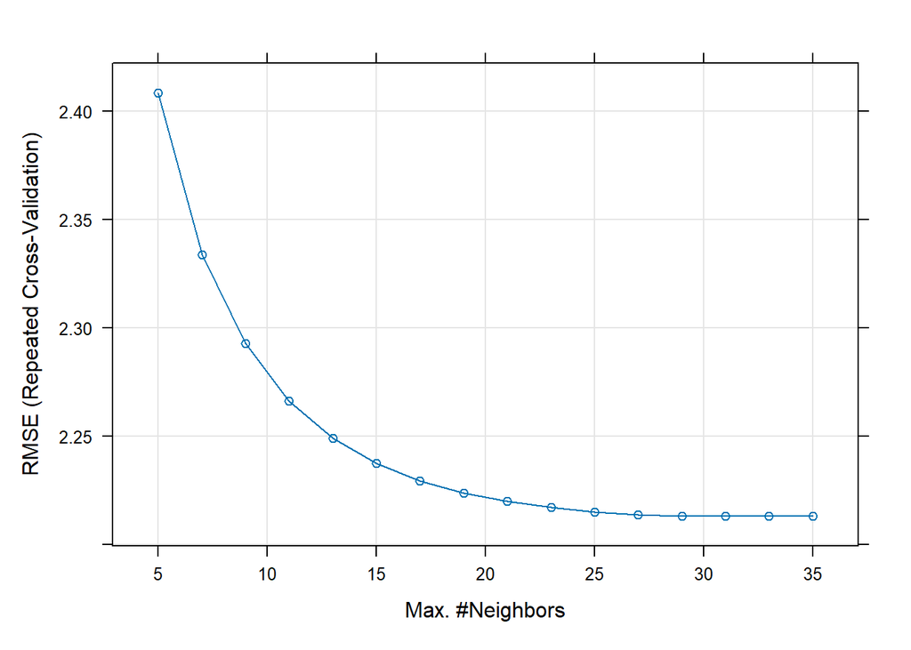

```r
set.seed(123)

knn_tune <- train(noVarModel,
                  data = training_noVar,
                  method = "kknn",
                  preProc=c('scale','center'),
                  tuneGrid = data.frame(kmax = seq(5, 35, 2), distance=2, kernel='optimal'),
                  trControl = ctrl)

plot(knn_tune)
```

We can see that RMSE decreases sharply between k = 5 and k = 25, then begins to stabilise. This suggests that the model benefits from increasing k up to a certain point, but further increases offer diminishing returns. Based on this, we narrow down our search grid to values between k = 23 and k = 33, where performance was most stable. This refined grid allows us to focus on the most promising range for optimal predictive accuracy.

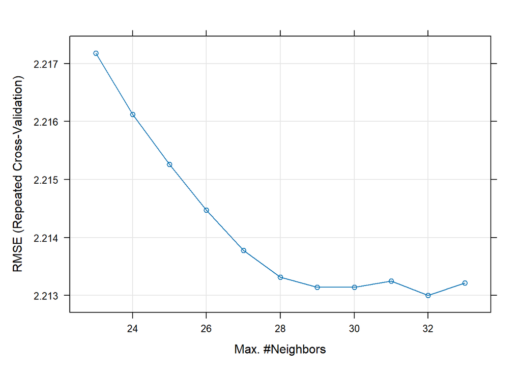

```r
set.seed(123)

knn_tune <- train(noVarModel,
                  data = training_noVar,
                  method = "kknn",
                  preProc=c('scale','center'),
                  tuneGrid = data.frame(kmax = seq(23, 33, 1), distance=2, kernel='optimal'),
                  trControl = ctrl)

plot(knn_tune)
```

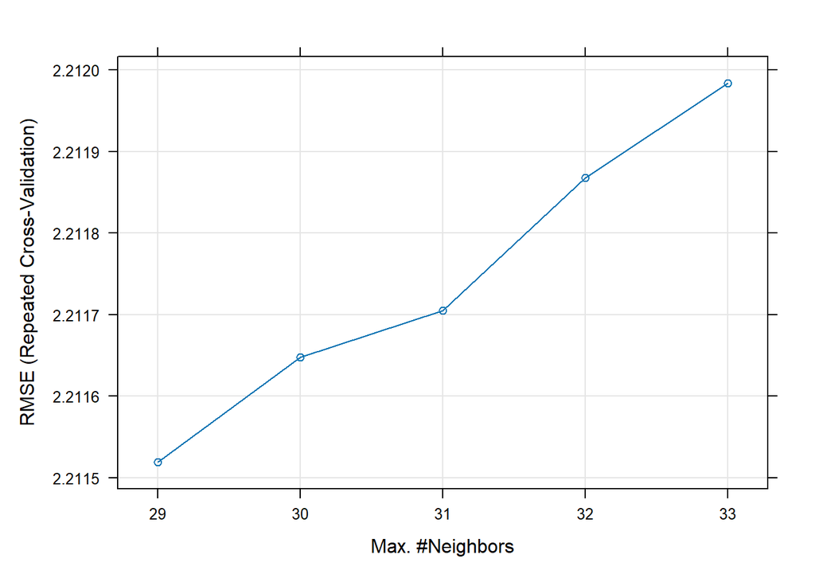

```r
knn_tune <- train(noVarModel,
                  data = training_noVar,
                  method = "kknn",
                  preProc=c('scale','center'),
                  tuneGrid = data.frame(
                    kmax=c(29, 30, 31, 32, 33),
                    distance=2,
                    kernel='optimal'),
                  trControl = ctrl)


plot(knn_tune)
```

```r
# saving results
test_results$knn <- predict(knn_tune, testing_noVar)
```

```r
postResample(pred = test_results$knn,  obs = test_results$original)
```

```
##      RMSE  Rsquared       MAE
## 2.2332080 0.3234542 1.7899677
```

### Random Forests

We now turn to Random Forest, an ensemble method that combines multiple decision trees’ averages to improve accuracy.

To fine-tune this model, we explore how different numbers of trees (ntree) affect prediction performance. We run a loop to train Random Forests with varying values of ntree, recording the resulting RMSE and R<sup>2</sup> to identify the best-performing configuration.Since this loop is computationally intensive, it is set to eval = FALSE in the final version of the document. However, the results from one complete run are saved and shown in the table below.

```r
ntree_values <- c(100, 250, 500, 750, 1000)
rf_results <- data.frame(ntree = ntree_values, RMSE = NA, Rsquared = NA)

# loop
for (i in seq_along(ntree_values)) {
  set.seed(123)
  rf_model <- train(
    noVarModel,
    data = training_noVar,
    method = "rf",
    trControl = ctrl,
    tuneLength = 5,
    ntree = ntree_values[i]
  )

  rf_results$RMSE[i] <- min(rf_model$results$RMSE)
  rf_results$Rsquared[i] <- max(rf_model$results$Rsquared)
}
```

```r
rf_results <- data.frame(
  ntree = c(100, 250, 500, 750, 1000),
  RMSE = c(2.164855, 2.160305, 2.160730, 2.158191, 2.158018),
  Rsquared = c(0.3399912, 0.3433136, 0.3437455, 0.3445126, 0.3443024)
)

rf_results
```

```
##   ntree     RMSE  Rsquared
## 1   100 2.164855 0.3399912
## 2   250 2.160305 0.3433136
## 3   500 2.160730 0.3437455
## 4   750 2.158191 0.3445126
## 5  1000 2.158018 0.3443024
```

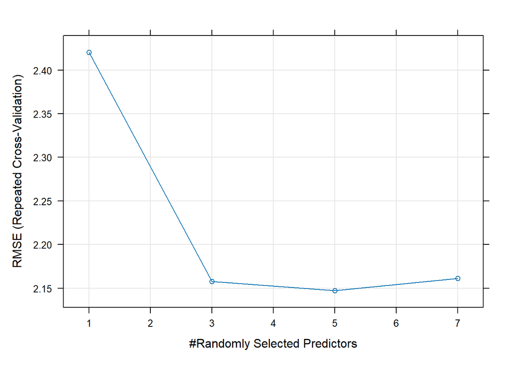

```r
rf_tune <- train(noVarModel,
                 data = training_noVar,
                 method = "rf",
                 preProc=c('scale','center'),
                 trControl = ctrl,
                 ntree = 500,
                 tuneGrid = data.frame(mtry=c(1,3,5,7)),
                 importance = TRUE)

# saving results
test_results$rf <- predict(rf_tune, testing_noVar)

plot(rf_tune)
```

The plot shows the effect of varying the number of randomly selected predictors (mtry) on the Random Forest model’s RMSE. As mtry increases from 1 to 3, RMSE drops substantially, indicating that the model benefits from considering more predictors at each split. The lowest RMSE is achieved at mtry = 5, after which the performance begins to plateau or slightly worsen. This suggests that selecting 5 predictors at each split offers the best balance between randomness and performance in our model.

```r
postResample(pred = test_results$rf,  obs = test_results$original)
```

```
##      RMSE  Rsquared       MAE
## 2.1906914 0.3416151 1.7302482
```

### Gradient Boosting

We now apply Gradient Boosting, an ensemble method that builds trees sequentially, with each one improving on the errors of the last.

Since tuning this model is highly computationally expensive, we saved the full model results using saveRDS() and later reload them with readRDS() to inspect the tuning grid. This lets us visualise performance across boosting rounds without rerunning the model.

```r
xgb_tune <- train(noVarModel,
                  data = training_noVar,
                  method = "xgbTree",
                  preProc=c('scale','center'),
                  objective="reg:squarederror",
                  trControl = ctrl,
                  tuneGrid = expand.grid(nrounds = c(100, 300, 500),
                                         max_depth = c(5,6,7),
                                         eta = c(0.01, 0.1, 1),
                                         gamma = c(1, 2, 3),
                                         colsample_bytree = c(1, 2),
                                         min_child_weight = c(1),
                                         subsample = c(0.2,0.5,0.8)))

saveRDS(xgb_tune, file = "xgb_tune_broad.rds")
```

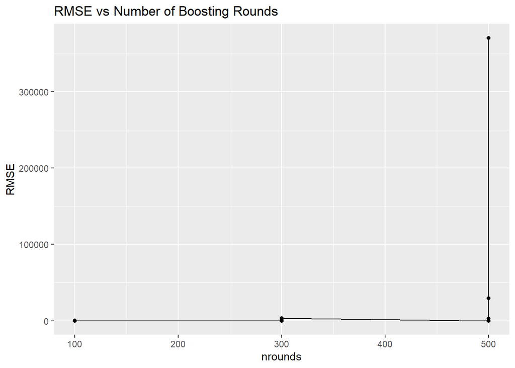

```r
xgb_tune_broad <- readRDS("xgb_tune_broad.rds")

xgb_tune_broad$results %>%
  dplyr::filter(gamma == 1, colsample_bytree == 1, subsample == 0.2) %>%   # filter for best parameters
  ggplot(aes(x = nrounds, y = RMSE)) +
  geom_line() +
  geom_point() +
  labs(title = "RMSE vs Number of Boosting Rounds", x = "nrounds", y = "RMSE")
```

Based on the visual and numerical evaluation, we finalise the model using the best hyperparameter combination (nrounds = 300) in the following lightweight training.

```r
xgb_tune <- train(noVarModel,
                  data = training_noVar,
                  method = "xgbTree",
                  preProc = c('scale', 'center'),
                  objective = "reg:squarederror",
                  trControl = ctrl,
                  tuneGrid = expand.grid(nrounds = 300,
                                         max_depth = 5,
                                         eta = 0.01,
                                         gamma = 1,
                                         colsample_bytree = 1,
                                         min_child_weight = 1,
                                         subsample = 0.2
                                         ))

# saving results
test_results$xgb <- predict(xgb_tune, testing_noVar)

postResample(pred = test_results$xgb,  obs = test_results$original)
```

```
##      RMSE  Rsquared       MAE
## 2.1863869 0.3481945 1.7272249
```

While XGBoost performed well, I was unable to explore a broader set of hyperparameter combinations due to computational constraints affecting time constraints. It is possible that a wider search would yield better results, but given the trade-off between time and marginal gains, simpler models like LM remained competitive in our setting.

### Neural Networks

We now apply a Neural Network model, a flexible non-linear approach capable of capturing complex patterns through layered transformations of the input data.

To identify the most effective neural network configuration, we test several combinations of hidden layer size and weight decay parameters.

```r
nn_tune <- train(noVarModel,
                 data = training_noVar,
                 method = "nnet",
                 preProc=c('scale','center'),
                 trControl = ctrl,
                 tuneGrid = expand.grid(
                   size = c(3, 5, 7, 10),
                   decay = c(0, 0.001, 0.01, 0.1)),
                 linout = TRUE)
```

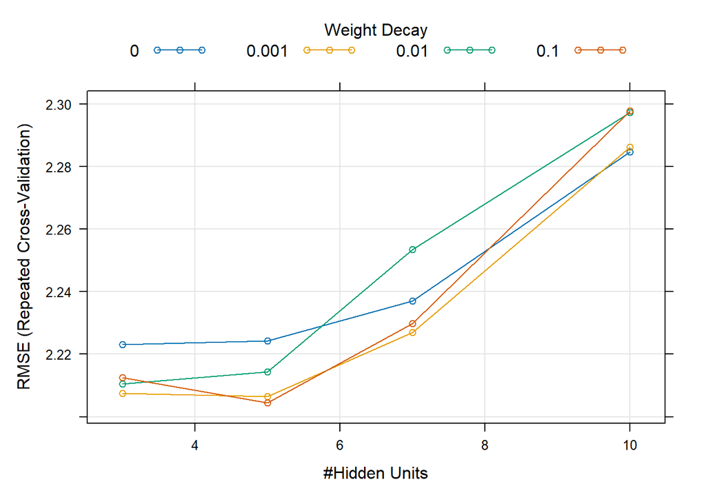

```r
# saving results
test_results$nn <- predict(nn_tune, testing_noVar)

plot(nn_tune)
```

```r
nn_tune$bestTune
```

```
##   size decay
## 8    5   0.1
```

```r
postResample(pred = test_results$nn,  obs = test_results$original)
```

```
##      RMSE  Rsquared       MAE
## 2.2261912 0.3192269 1.7530316
```

## Comparing ML models

Now we are going to compare our machine learning models in terms of how they prioritise different predictors. By examining variable importance across models, we gain insight into which features consistently drive predictions and how different algorithms interpret the underlying data structure.

### Variable Importance

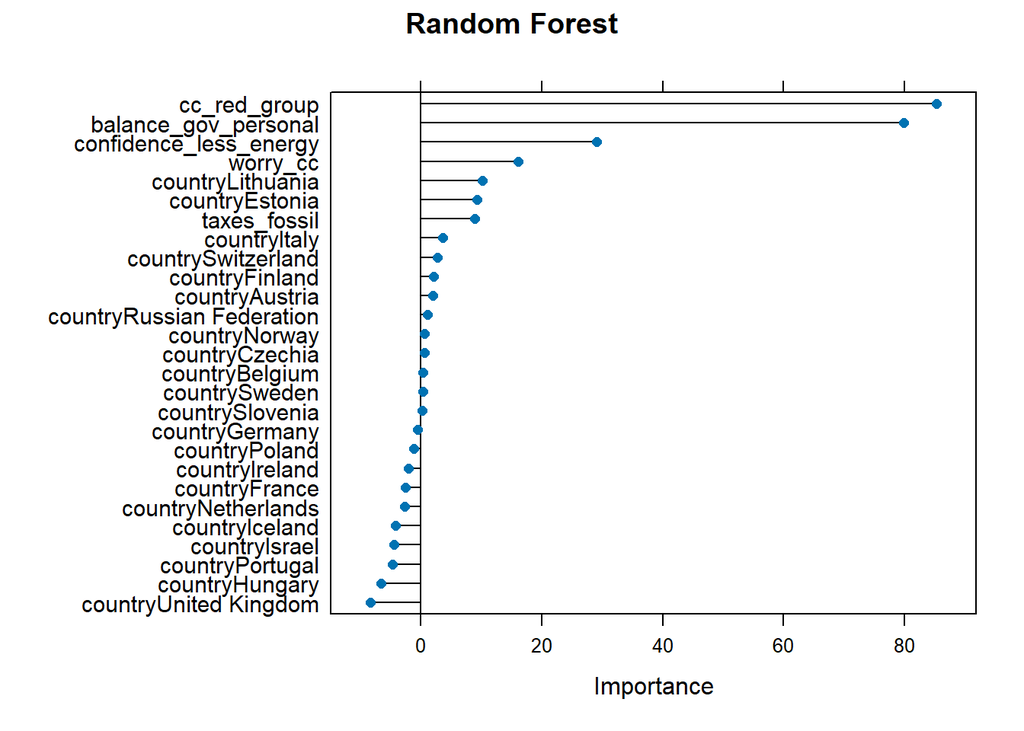

```r
par(mfrow = c(2, 2))

plot(varImp(rf_tune, scale = F), scales = list(y = list(cex = .95)), main = "Random Forest")
```

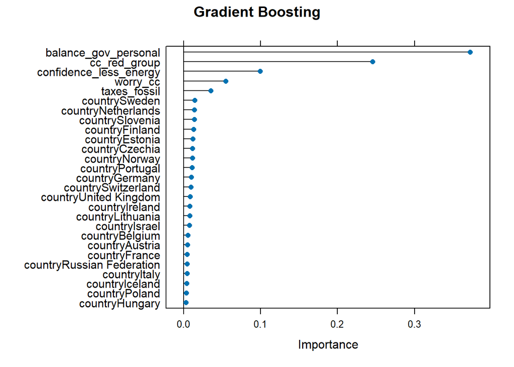

```r
plot(varImp(xgb_tune, scale = F), scales = list(y = list(cex = .95)), main = "Gradient Boosting")
```

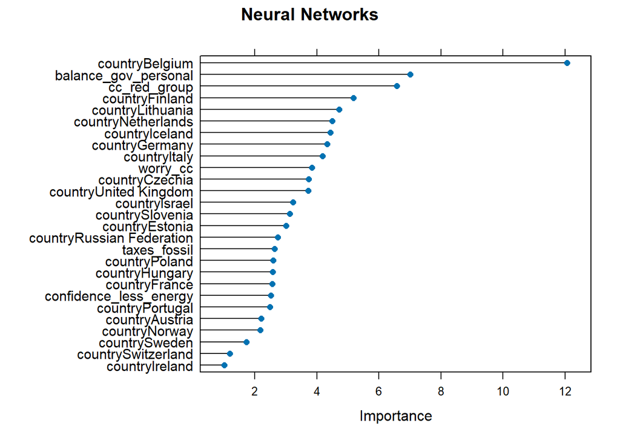

```r
plot(varImp(nn_tune, scale = F), scales = list(y = list(cex = .95)), main = "Neural Networks")
```

```r
varImp(rf_tune, scale = F)$importance |>
  tibble::rownames_to_column("variable") |>
  dplyr::arrange(desc(Overall)) |>
  dplyr::slice_head(n = 5)
```

```
##                 variable  Overall
## 1           cc_red_group 85.31191
## 2   balance_gov_personal 79.82821
## 3 confidence_less_energy 29.11926
## 4               worry_cc 16.11386
## 5       countryLithuania 10.15273
```

```r
varImp(xgb_tune, scale = F)$importance |>
  tibble::rownames_to_column("variable") |>
  dplyr::arrange(desc(Overall)) |>
  dplyr::slice_head(n = 5)
```

```
##                 variable    Overall
## 1   balance_gov_personal 0.37236443
## 2           cc_red_group 0.24549600
## 3 confidence_less_energy 0.09972039
## 4               worry_cc 0.05469513
## 5           taxes_fossil 0.03559050
```

```r
varImp(nn_tune, scale = F)$importance |>
  tibble::rownames_to_column("variable") |>
  dplyr::arrange(desc(Overall)) |>
  dplyr::slice_head(n = 5)
```

```
##               variable   Overall
## 1       countryBelgium 12.064803
## 2 balance_gov_personal  7.012111
## 3         cc_red_group  6.580066
## 4       countryFinland  5.169464
## 5     countryLithuania  4.712490
```

```r
par(mfrow = c(1, 1))
```

Overall, while `balance_gov_personal` and `cc_red_group` emerge as robust predictors across models, the relative importance of other features (especially `country` variables) varies depending on the model structure. This suggests that different algorithms may be capturing complementary patterns in the data.

### Partial dependence

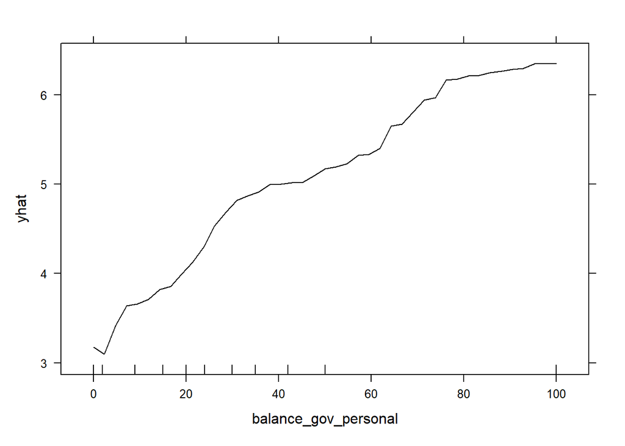

```r
par(mfrow = c(1, 3))  # 1 row, 3 plots

partial(rf_tune, pred.var = "balance_gov_personal", plot = TRUE, rug = TRUE)
```

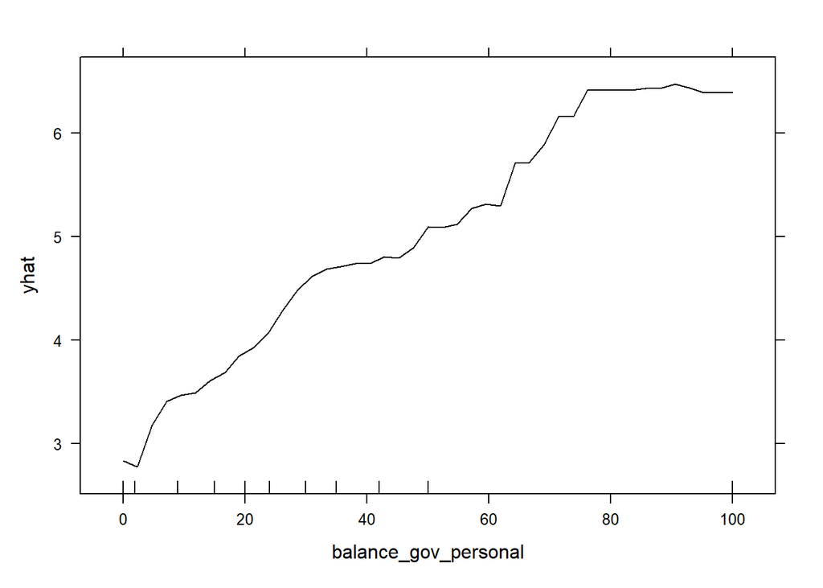

```r
partial(xgb_tune, pred.var = "balance_gov_personal", plot = TRUE, rug = TRUE)
```

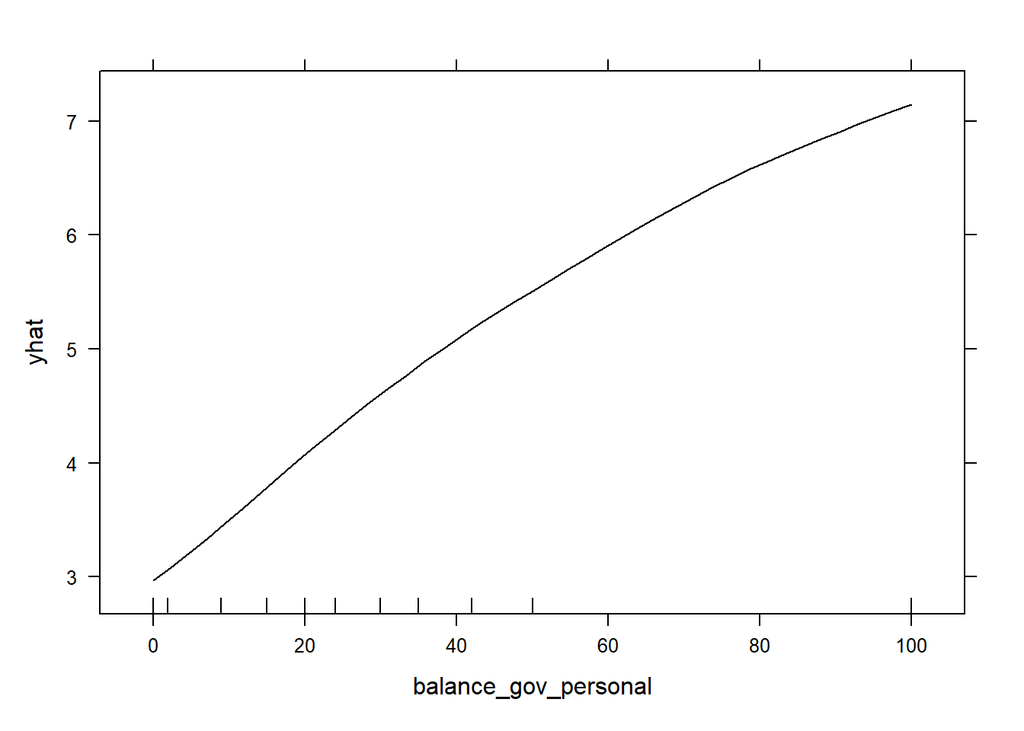

```r
partial(nn_tune, pred.var = "balance_gov_personal", plot = TRUE, rug = TRUE)
```

Comparing the three plots we see:

- In the Random Forest model, `balance_gov_personal` shows a clear positive effect: higher balance scores lead to steadily higher predicted support for climate action. While the line is obviouly non-linear, it does follow a rather straight trend upwards.
- The XGBoost model also shows a positive association between `balance_gov_personal` and support, though with a slightly sharper increase between scores of 60 and 80, then flattening at the top.
- The neural network shows the strongest linear relationship, with a smooth and steep rise in predicted support as `balance_gov_personal` increases, suggesting it interprets the variable’s influence as highly consistent across the scale.

All in all, all three models agree on a strong positive association between `balance_gov_personal` and support for climate action. They differ in how they capture the relationship’s shape: ranging from linear (neural networks), to mildly non-linear (Random Forest), to more complex with thresholds (XGBoost). This highlights how model architecture can influence the interpretation of variable effects.

Now we take a look at `worry_cc`.

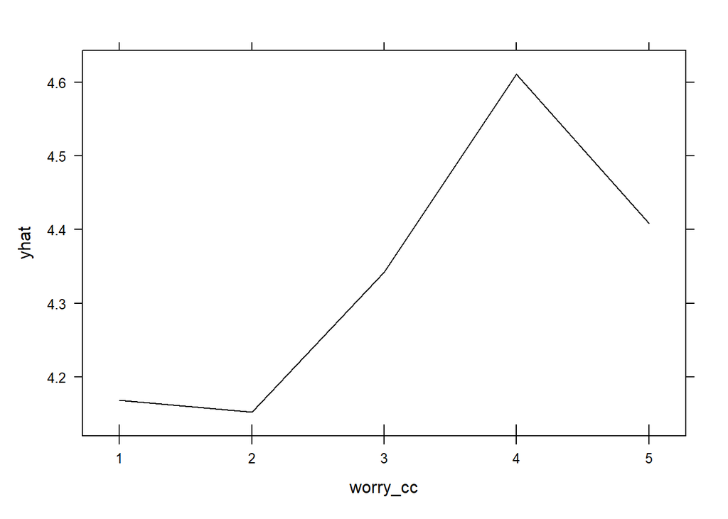

```r
par(mfrow = c(1, 3))  # 1 row, 3 plots

partial(rf_tune, pred.var = "worry_cc", plot = TRUE, rug = TRUE)
```

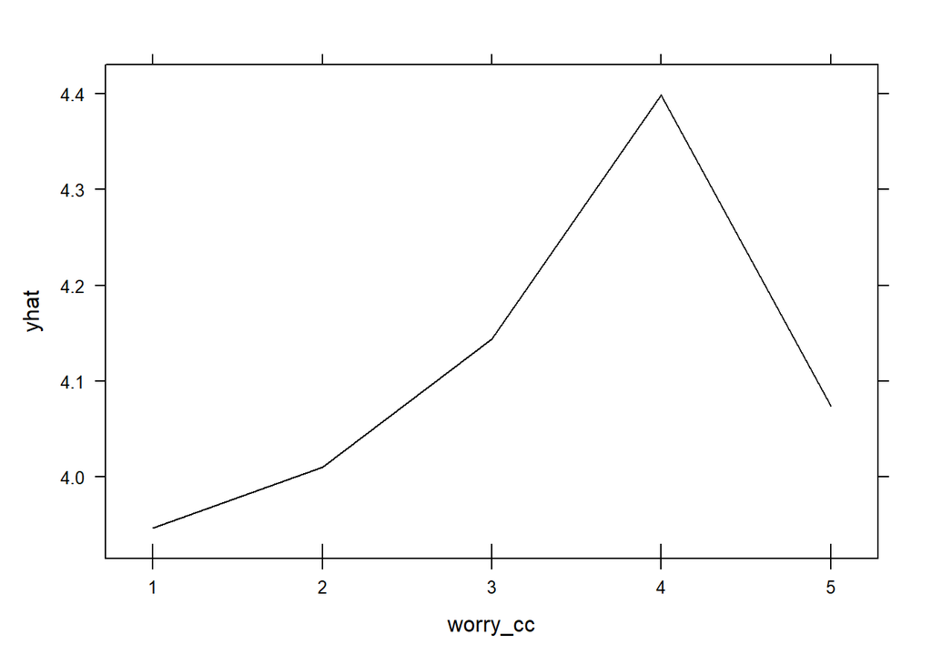

```r
partial(xgb_tune, pred.var = "worry_cc", plot = TRUE, rug = TRUE)
```

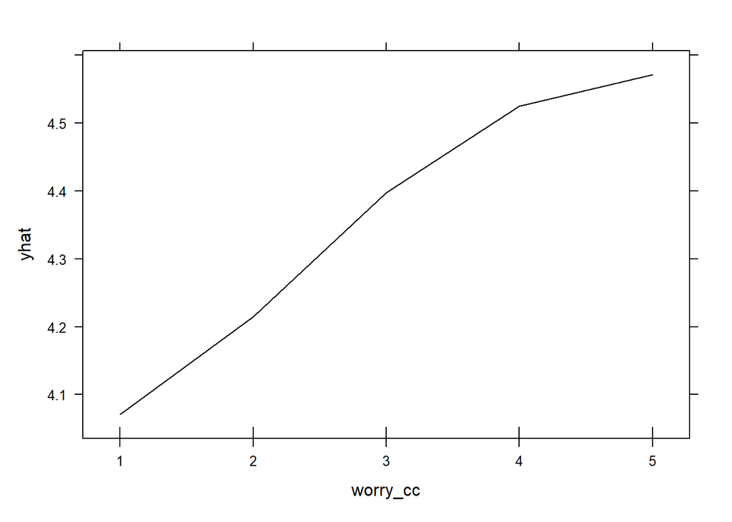

```r
partial(nn_tune, pred.var = "worry_cc", plot = TRUE, rug = TRUE)
```

```r
par(mfrow = c(1, 1))
```

For `worry_cc` we can appreciate the following:

- In the Random Forest model, `worry_cc` shows a non-linear effect. Predicted support rises notably from levels 2 to 4 but then declines at level 5. This suggests the model identifies a tipping point, after which additional worry does not translate into higher support, and may even slightly reduce it.
- In the XGBoost model, `worry_cc` also shows a non-linear relationship with predicted support for climate action. Support increases from levels 1 to 4, peaking at 4, but then unexpectedly drops at level 5. This suggests again that the model captures a threshold effect, where very high levels of worry might not further increase support or could reflect a different respondent profile.
- In the neural network model, `worry_cc` shows a clear linear effect: as worry about climate change increases, predicted support for action steadily rises. Unlike the tree-based models, there is no dip at the highest level, suggesting the model treats greater concern as uniformly predictive of higher support.

Overall, while all three models identify a positive association between worry about climate change and support for action, their interpretations differ. The Random Forest and XGBoost models suggest a non-linear, threshold-like effect, where support peaks and then slightly declines at the highest worry level. In contrast, the neural network captures a consistent, linear increase in support, implying a more straightforward relationship between concern and willingness to act.

## Comparing predictions

In this final section, we evaluate how well our different models perform by directly comparing their prediction outputs. Beyond standard metrics like RMSE and R-squared, we focus on mean absolute error (MAE) to assess accuracy in intuitive terms. We then build an ensemble model that averages the predictions of the top-performing approaches, aiming to boost performance through model combination. Finally, we explore prediction intervals using a simple conformal prediction framework to visualise model uncertainty and identify observations where predictions diverge from reality. This comprehensive comparison helps us understand not only which model predicts best but also where and why they might fail.

### MAE

We start by comparing models using the MAE.

```r
apply(test_results[-1], 2, function(x) mean(abs(x - test_results$original)))
```

```
##       lm      alm    ridge    lasso   glmnet      frw      seq       bw
## 1.707747 1.702919 1.707876 1.709088 1.713278 1.725040 2.227687 1.721889
##      knn       rf      xgb       nn
## 1.789968 1.730248 1.727225 1.753032
```

This suggests that statistically engineered regression models outperform machine learning models in terms of predictive accuracy on this task.

### ML Model combination: Ensemble

To boost predictive performance, we combine the strengths of our 3 top machine learning models by creating an ensemble through simple averaging.

```r
test_results$comb = (test_results$rf + test_results$xgb + test_results$nn)/3 #in this case we consider the top 3

postResample(pred = test_results$comb,  obs = test_results$original)
```

```
##      RMSE  Rsquared       MAE
## 2.1734626 0.3521647 1.7174080
```

```r
yhat = test_results$comb
head(yhat)
```

```
## [1] 4.506151 2.302502 5.666682 2.268007 1.812923 3.037229
```

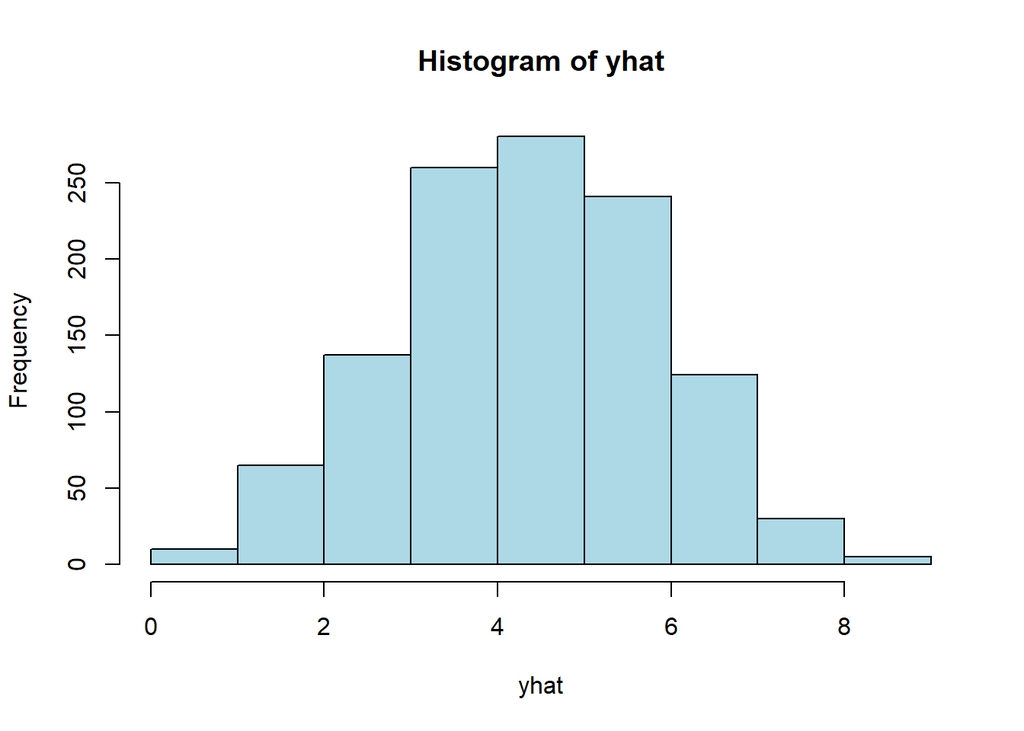

```r
hist(yhat, col="lightblue")
```

The histogram of the ensemble predictions (yhat) shows a roughly symmetric, bell-shaped distribution centered around values 4–5. This suggests the model consistently predicts moderate levels of support, with few extreme values on either end. It indicates stable and reasonable output, but could also imply limited sensitivity to very high or very low responses.

### Prediction Intervals

To assess the reliability of our predictions, we construct prediction intervals to quantify the uncertainty around each predicted value.

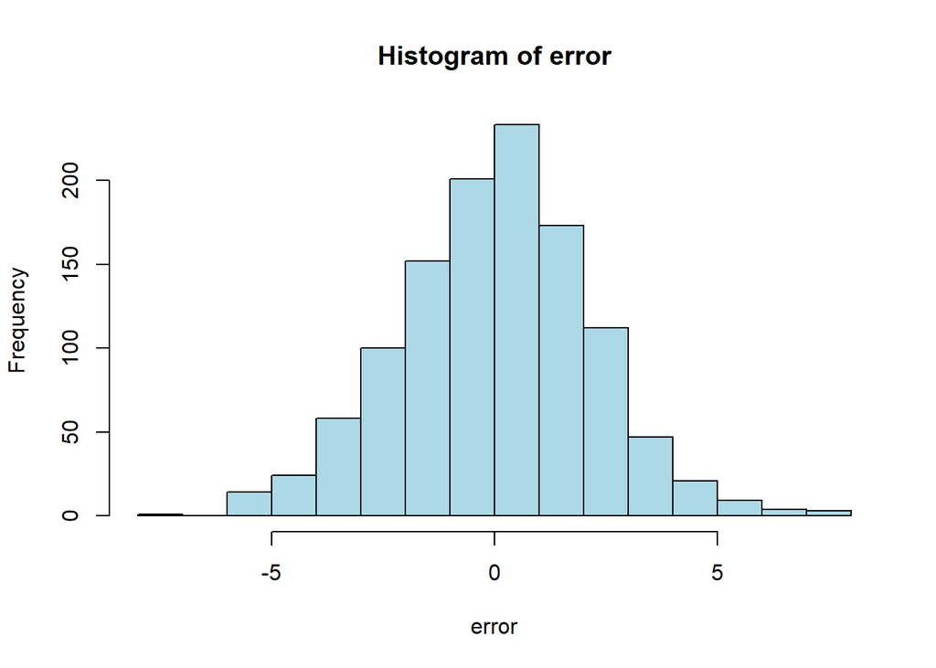

```r
y = test_results$original
error = y-yhat
hist(error, col="lightblue")
```

The error distribution is centred around zero and appears roughly normal, indicating that the ensemble model does not systematically over- or under-predict, with most errors being small and a few larger deviations on either side.

To construct prediction intervals, we followed the conformal prediction approach provided in class, using the first 100 residuals as a reference for estimating uncertainty. However, the original implementation applied the 5th and 95th quantiles of raw residuals directly, which led to overly wide or inaccurate intervals. To improve reliability, we adjusted the method by applying symmetric quantiles of absolute residuals instead. This preserves the spirit of conformal prediction while ensuring the intervals better reflect typical prediction error. The adjustment avoids overfitting to early residual noise and yields more interpretable, balanced intervals.

```r
noise = error[1:100]

# elasticnet
yhat = test_results$glmnet

lwr <- yhat[101:length(yhat)] - quantile(abs(noise), 0.95, na.rm = T)
upr <- yhat[101:length(yhat)] + quantile(abs(noise), 0.95, na.rm = T)

predictions = data.frame(real=y[101:length(y)],
                         fit=yhat[101:length(yhat)],
                         lwr=lwr, upr=upr)

predictions = predictions %>% mutate(out=factor(if_else(real<lwr | real>upr,1,0)))

cat("ElasticNet:", mean(predictions$out==1), "\n\n")
```

```
## ElasticNet: 0.03231939
```

```r
# ensemble
yhat = test_results$comb

lwr <- yhat[101:length(yhat)] - quantile(abs(noise), 0.95, na.rm = T)
upr <- yhat[101:length(yhat)] + quantile(abs(noise), 0.95, na.rm = T)

predictions = data.frame(real=y[101:length(y)],
                         fit=yhat[101:length(yhat)],
                         lwr=lwr, upr=upr)

predictions = predictions %>% mutate(out=factor(if_else(real<lwr | real>upr,1,0)))

cat("Ensemble:", mean(predictions$out==1), "\n")
```

```
## Ensemble: 0.03326996
```

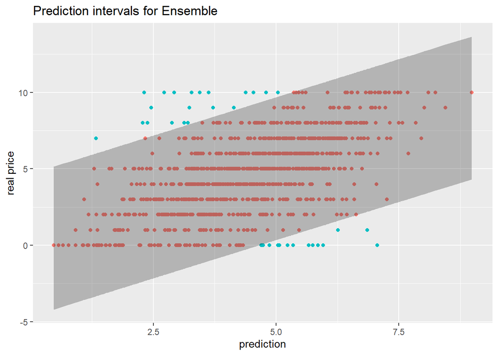

```r
ggplot(predictions, aes(x=fit, y=real))+
  geom_point(aes(color=out)) + theme(legend.position="none") +
  geom_ribbon(data=predictions,aes(ymin=lwr,ymax=upr),alpha=0.3) +
  labs(title = "Prediction intervals for Ensemble", x = "prediction",y="real price")
```

The plot shows the prediction intervals around the ensemble model’s estimates. Most observed values (in red) fall within the shaded confidence band, confirming good coverage. Outliers (in blue) lie outside the interval and suggest cases where the model under- or overestimates support more substantially. These could point to unmodelled factors or areas where the model is less reliable.

## Conclusions: Regression

```r
apply(test_results[-1], 2, function(x) {
  cor(x, test_results$original, use = "complete.obs")^2
}) %>%
  enframe(name = "model", value = "R_squared") %>%
  arrange(desc(R_squared))
```

```
## # A tibble: 13 × 2
##    model  R_squared
##    <chr>      <dbl>
##  1 glmnet    0.361
##  2 ridge     0.361
##  3 lm        0.361
##  4 lasso     0.361
##  5 alm       0.358
##  6 comb      0.352
##  7 bw        0.351
##  8 frw       0.351
##  9 xgb       0.348
## 10 rf        0.342
## 11 knn       0.323
## 12 nn        0.319
## 13 seq       0.0154
```

Despite tuning and ensemble strategies, model performance plateaued around 35% of explained variance. This indicates that the dataset may not contain enough signal to fully capture the outcome variable. Nonetheless, the modelling process shed light on variables that consistently mattered, such as `balance_gov_personal`, `cc_red_group`, and `worry_cc` and illustrated how different algorithms interpret these patterns.

# Conclusion

This project explored two predictive tasks to better understand individual perceptions and attitudes regarding climate change.

In the classification task, we aimed to predict belief in human-caused climate change. While no model achieved perfect accuracy, the best-performing ones highlighted the importance of attitudinal and sociodemographic variables, achieving modest predictive success.

A particularly notable finding was the predictive power of `country` itself. In several models, national origin acted as a standalone predictor for climate beliefs and perceived responsibility, underscoring the weight of social and political context in shaping environmental attitudes.

Finally, it is important to acknowledge that all variables represent survey responses: they reflect how participants choose to portray themselves, rather than objective truths. This self-reported nature introduces an interpretive layer: people may express what they *believe* they should think or do, rather than what they truly feel or act upon. As such, our findings offer, instead of objective truths about climate action trends, rather insight into *public narratives and self-perceptions about climate change*.

[^1]: At some point of this whole assignment, this number was reduced to 4999, and I cannot quite figure out why, but it does not seem to change the results.
[^2]: Remember that while we have 9 variables, some of these variables are actually factors, so their dummy variables show up as individual features.